# Analyze Patterns and Predict Avocado Prices

Fakhrul Mu’minin

```r
knitr::opts_chunk$set(warning = FALSE, message = FALSE, fig.width = 10, fig.height = 5)
```

# Welcome

This project aims to identify cyclical patterns and predict avocado prices in several US markets. To achieve this goal, I use the method of analysis and time series forecasting. I will analyze the patterns of months, years, seasons, and several regions of the US. in addition, an interactive plot will be created to provide better information for understanding it.

## Data Source

This data comes from the Hass Avocado Board website in May 2018. The tables in this dataset represent the 2018 weekly retail scan data for national retail volume (units) and prices. Starting in 2013, the tables on this dataset reflect an expanded multioutlet retail data set. The average avocado price in the table reflects the cost per avocado.

I found this data set on the Kaggle site This is a link from the dataset: https://www.kaggle.com/neuromusic/avocado-prices

## Data Preparation

Before entering into exploratory data analysis, I made data preparations where there was a process of checking data, deleting unnecessary columns, renaming columns, converting data types, adding columns as needed.

Let’s do it all!

```r
### Library Used ###
library(tidyverse)
library(skimr)
library(highcharter)
library(plotly)
library(tibbletime)
library(cowplot)
library(forecast)
library(ggthemes)
library(ggcorrplot)

### Data Collection ###
df <- read.csv("avocado.csv")

### Data Checking ###
skim(df)
```

Data summary

| Name | df |
| --- | --- |
| Number of rows | 18249 |
| Number of columns | 14 |
| _______________________ |  |
| Column type frequency: |  |
| character | 3 |
| numeric | 11 |
| ________________________ |  |
| Group variables | None |

**Variable type: character**

| skim_variable | n_missing | complete_rate | min | max | empty | n_unique | whitespace |
| --- | --- | --- | --- | --- | --- | --- | --- |
| Date | 0 | 1 | 10 | 10 | 0 | 169 | 0 |
| type | 0 | 1 | 7 | 12 | 0 | 2 | 0 |
| region | 0 | 1 | 4 | 19 | 0 | 54 | 0 |

**Variable type: numeric**

| skim_variable | n_missing | complete_rate | mean | sd | p0 | p25 | p50 | p75 | p100 | hist |
| --- | --- | --- | --- | --- | --- | --- | --- | --- | --- | --- |
| X | 0 | 1 | 24.23 | 15.48 | 0.00 | 10.00 | 24.00 | 38.00 | 52.00 | ▇▆▆▆▆ |
| AveragePrice | 0 | 1 | 1.41 | 0.40 | 0.44 | 1.10 | 1.37 | 1.66 | 3.25 | ▂▇▅▁▁ |
| Total.Volume | 0 | 1 | 850644.01 | 3453545.36 | 84.56 | 10838.58 | 107376.76 | 432962.29 | 62505646.52 | ▇▁▁▁▁ |
| X4046 | 0 | 1 | 293008.42 | 1264989.08 | 0.00 | 854.07 | 8645.30 | 111020.20 | 22743616.17 | ▇▁▁▁▁ |
| X4225 | 0 | 1 | 295154.57 | 1204120.40 | 0.00 | 3008.78 | 29061.02 | 150206.86 | 20470572.61 | ▇▁▁▁▁ |
| X4770 | 0 | 1 | 22839.74 | 107464.07 | 0.00 | 0.00 | 184.99 | 6243.42 | 2546439.11 | ▇▁▁▁▁ |
| Total.Bags | 0 | 1 | 239639.20 | 986242.40 | 0.00 | 5088.64 | 39743.83 | 110783.37 | 19373134.37 | ▇▁▁▁▁ |
| Small.Bags | 0 | 1 | 182194.69 | 746178.51 | 0.00 | 2849.42 | 26362.82 | 83337.67 | 13384586.80 | ▇▁▁▁▁ |
| Large.Bags | 0 | 1 | 54338.09 | 243965.96 | 0.00 | 127.47 | 2647.71 | 22029.25 | 5719096.61 | ▇▁▁▁▁ |
| XLarge.Bags | 0 | 1 | 3106.43 | 17692.89 | 0.00 | 0.00 | 0.00 | 132.50 | 551693.65 | ▇▁▁▁▁ |
| year | 0 | 1 | 2016.15 | 0.94 | 2015.00 | 2015.00 | 2016.00 | 2017.00 | 2018.00 | ▇▇▁▇▂ |

```r
sum(duplicated(df))
```

```
## [1] 0
```

```r
### Delete Column ###
df <- select(df, -X)
### Convert Data Types and Added a New Column ###
df$Date <- as.Date(as.character(df$Date, format="%Y-%m-%d"))
df$month <- format(as.Date(df$Date), "%b")
df$week <- format(as.Date(df$Date), "%w")
df$type <- as.factor(df$type)
df$year <- as.factor(df$year)
df$region <- as.factor(df$region)
df$month <- as.factor(df$month)
df$season <- ifelse(df$month %in% c("Mar","Apr","May"), "Spring",
                    ifelse(df$month %in% c("Jun","Jul","Aug"), "Summer",
                           ifelse(df$month %in% c("Sep","Oct","Nov"), "Fall", "Winter")))
### Rename the column ###
df <- rename(df, c("Small.Hass" = "X4046", "Large.Hass" = "X4225", "XLarge.Hass" = "X4770"))
### Sort Data by Date ###
df <- arrange(df, Date)
```

# Quick Analysis

In this section, I will focus on time series analysis before getting into time series forecasting.

## Exploratory Data Analysis

Before I start time series analysis I will give a brief analysis of the data in the exploratory data analysis section regarding data distribution, the relationship between variables, the relationship between price and volume, market volume analysis, seasonality analysis, area analysis.

### Distribution Plot of Avocado Prices

```r
### Distribution Plot of Avocado Prices ###
c <- df %>% select(type, AveragePrice)  %>%  filter(type == "conventional")
o <- df %>% select(type, AveragePrice)  %>% filter(type == "organic")
hchart(density(c$AveragePrice), type="area", name="Conventional", color="green") %>%
  hc_add_series(density(o$AveragePrice), type="area", name="Organic", color="red") %>%
  hc_add_theme(hc_theme_flat()) %>%
  hc_title(text = "Distribution of Avocado Average Price") %>%
  hc_xAxis(labels = list(format = "{value}"),
           title = list(text = "Average Price of Avocado"))
```

[interactive chart not shown]

We can see the avocado price distribution plot above shows that: * The distribution of the average price of avocado shows to the left which has many values converging at value 1. * Meanwhile, the average distribution of avocado prices shows a fairly stable direction in the middle and converges a lot at a value of 1.5.

### The Relationship Between Price and Volume

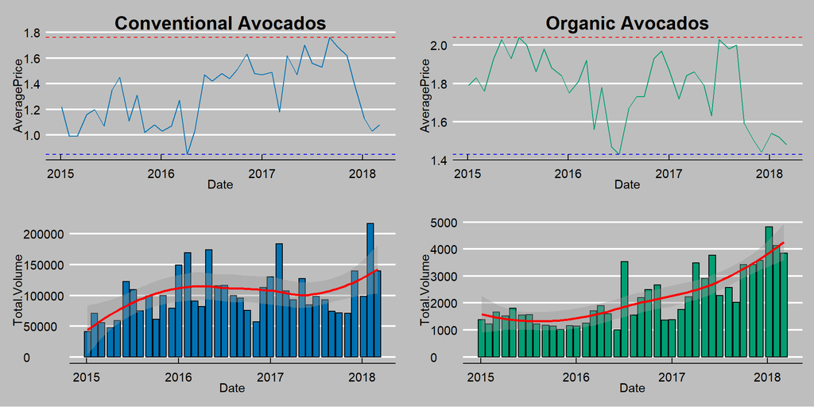

```r
#Filter by type
organic <- df %>% select(Date, month, year, type, AveragePrice, Total.Volume) %>% filter(type=="organic")
conventional <- df %>% select(Date, month, year, type, AveragePrice, Total.Volume) %>% filter(type=="conventional")
#Organic Avocado
organic <- as_tbl_time(organic, index=Date)
organic <- as_period(organic, 'month')
#Conventional Avocado
conventional <- as_tbl_time(conventional, index = Date)
conventional <- as_period(conventional, 'month')

### The relationship between price and volume ###
options(repr.plot.width = 8, repr.plot.height = 6)
conventional_monthly <- conventional %>%
  ggplot(aes(x=Date, y=AveragePrice)) + geom_line(color = "#0072B2") + theme_economist() +
  theme(plot.title = element_text(hjust = 0.5), plot.background = element_rect(fill = "grey")) +
  labs(title = "Conventional Avocados") + geom_hline(yintercept = max(conventional$AveragePrice), linetype="dashed", color="red") +
  geom_hline(yintercept = min(conventional$AveragePrice), linetype="dashed", color = "blue")

conventional_volume <- conventional %>%
  ggplot(aes(x=Date, y=Total.Volume)) + geom_bar(stat = 'identity', fill="#0072B2", color="black") + theme_economist() +
  theme(plot.title = element_text(hjust = 0.5), plot.background = element_rect(fill = "grey")) +
  geom_smooth(method = "loess", color="red")

organic_monthly <- organic %>%
  ggplot(aes(x=Date, y=AveragePrice)) + geom_line(color = "#009E73") + theme_economist() +
  theme(plot.title = element_text(hjust = 0.5), plot.background = element_rect(fill = "grey")) +
  labs(title = "Organic Avocados") + geom_hline(yintercept = max(organic$AveragePrice), linetype="dashed", color="red") +
  geom_hline(yintercept = min(organic$AveragePrice), linetype="dashed", color="blue")

organic_volume <- organic %>%
  ggplot(aes(x=Date, y=Total.Volume)) + geom_bar(stat = 'identity', fill="#009E73", color="black") +
  theme_economist() + theme(plot.title = element_text(hjust = 0.5), plot.background = element_rect(fill = "grey")) +
  geom_smooth(method = "loess", color="red")

plot_grid(conventional_monthly, organic_monthly, conventional_volume, organic_volume, nrow=2, ncol=2)
```

In the graph above, we can see that the price of avocados is influenced by the volume.

At conventional avocado prices we can see that prices will fall when volume increases and vice versa. the same is the case with avocado prices. Then we can see that a big decline occurred in 2016 for conventional avocados, while for organic avocados a large decline in prices occurred in 2016 and 2017.

### Avocado Prices by Season

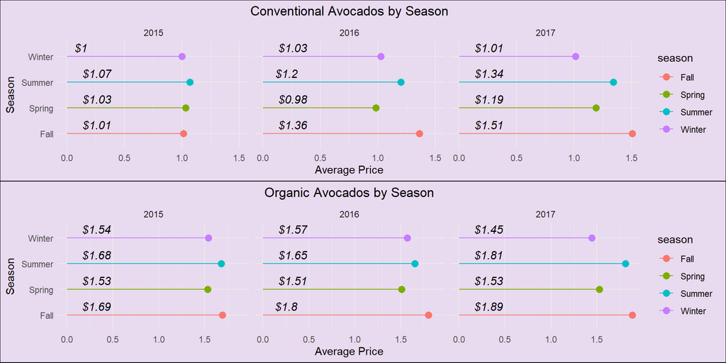

```r
spc <- df %>% select(season, year, AveragePrice, type) %>%
  filter(type == "conventional", year == c("2015","2016","2017")) %>%
  group_by(season, year) %>%
  summarize(avg=mean(AveragePrice)) %>%
  ggplot(aes(x=season, y=avg, color=season)) +
  geom_point(size=3) +
  geom_segment(aes(x=season, xend=season,
                   y=0, yend=avg)) +
  coord_flip() +
  facet_wrap(~year) + theme_minimal() +
  theme(plot.title = element_text(hjust = 0.5),
        plot.background = element_rect(fill="#E8DAEF")) +
  labs(title = "Conventional Avocados by Season", x="Season", y="Average Price") +
  geom_text(
    aes(
      x = season,
      y = 0.01,
      label = paste0("$", round(avg, 2))
    ),
    hjust = -0.5,
    vjust = -0.5,
    size = 4,
    colour = "black",
    fontface = "italic",
    angle = 360
  )

spo <- df %>% select(season, year, AveragePrice, type) %>%
  filter(type == "organic", year == c("2015","2016","2017")) %>%
  group_by(season, year) %>%
  summarize(avg=mean(AveragePrice)) %>%
  ggplot(aes(x=season, y=avg, color=season)) +
  geom_point(size=3) +
  geom_segment(aes(x=season, xend=season,
                   y=0, yend=avg)) +
  coord_flip() +
  facet_wrap(~year) + theme_minimal() +
  theme(plot.title = element_text(hjust = 0.5),
        plot.background = element_rect(fill="#E8DAEF")) +
  labs(title = "Organic Avocados by Season", x="Season", y="Average Price") +
  geom_text(
    aes(
      x = season,
      y = 0.01,
      label = paste0("$", round(avg, 2))
    ),
    hjust = -0.5,
    vjust = -0.5,
    size = 4,
    colour = "black",
    fontface = "italic",
    angle = 360
  )

plot_grid(spc, spo, nrow = 2)
```

In the graph, we can see that avocado prices are also supported by the season.

# Time Series Analysis

In this section, I will analyze quickly using the time series analysis method.

Why do I use the time series analysis method ? Because time series data analysis is a reliable forecasting tool. “time” is an important factor that can ensure success in business and “time series” can be divided into components that are used to systematically understand, analyze, model and forecast which can also be measured daily, monthly, yearly, etc. other. Therefore, time series analysis is quite important in terms of industry demand and relevance, especially in forecasting.

The following is what is discussed in time series analysis: * Decompose time series data into trends, seasonal, and remainder. * Annual time series analysis. * Monthly time series analysis. * Weekly time series analysis.

## Time Series Data Decomposition

First, in this step I will decompose the time series data in more detail based on the trend, seasonal, and remainder. I hope that the results of this decomposition can find out the behavior of avocado prices in several US markets.

Time series pattern types: * Trend: describes the development of a long-term series. Trends occur when there is a continuous direction of up or down in the data. * Cyclic: describes repeated but non-periodic fluctuations. The duration of these fluctuations is usually at least two years. * Seasonal: Describes the seasonality that exists in time series data. seasonality occurs at a certain time period can be weekly, monthly, quarterly, etc. * Remainder: describes random or irregular influences. this is leftover after removing all other components of the time series data.

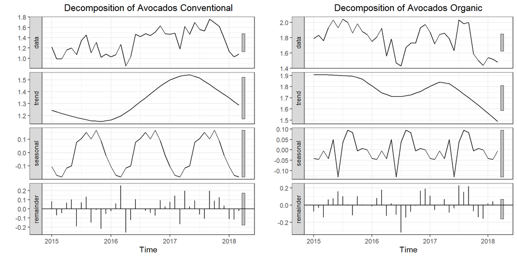

```r
tsc <- ts(conventional[,5], start = c(2015,1), frequency = 12)
tso <- ts(organic[,5], start = c(2015,1), frequency = 12)

dc <- stl(tsc[,1], s.window = "periodic")
do <- stl(tso[,1], s.window = "periodic")

plot.dc <- autoplot(dc) +
  ggtitle("Decomposition of Avocados Conventional") +
  theme_bw() + theme(plot.title = element_text(hjust = 0.5))
plot.do <- autoplot(do) +
  ggtitle("Decomposition of Avocados Organic") +
  theme_bw() + theme(plot.title = element_text(hjust = 0.5))

plot_grid(plot.dc, plot.do, ncol = 2)
```

## Annual Time Series Data Analysis

[figure not shown]

```r
#Filter by type
byearc <- df %>% select(Date, month, year, type, AveragePrice, Total.Volume) %>% filter(type=="conventional", year == c("2015","2016","2017"))
byearo <- df %>% select(Date, month, year, type, AveragePrice, Total.Volume) %>% filter(type=="organic", year == c("2015","2016","2017"))
#Organic Avocado
byearo <- as_tbl_time(byearo, index=Date)
byearo <- as_period(byearo, 'month')
#Conventional Avocado
byearc <- as_tbl_time(byearc, index = Date)
byearc <- as_period(byearc, 'month')

tsc <- ts(byearo[,5], start = c(2015,1), frequency = 12)
tso <- ts(byearc[,5], start = c(2015,1), frequency = 12)

byear.conv <- ggseasonplot(tsc) +
  ylab("Average Avocado Price") +
  ggtitle("Conventional Avocados \n Polar Plot") +
  theme_minimal() + theme(plot.title = element_text(hjust = 0.5))
byearo.org <- ggseasonplot(tso) +
  ylab("Average Avocado Price") +
  ggtitle("Organic Avocados \n Polar Plot") +
  theme_minimal() + theme(plot.title = element_text(hjust = 0.5))

plot_grid(byear.conv, byearo.org, ncol = 2)
```

## Monthly Time Series Data Analysis

[figure not shown]

```r
month_conv <- ggsubseriesplot(tsc) +
  labs(title = "Conventional Avocados", x="Month", y="Average Price") + theme_economist() +
  theme(plot.title = element_text(hjust = 0.5))
month_org <- ggsubseriesplot(tso) +
  labs(title = "Organic Avocados", x="Months", y="Average Price") +
  theme_economist() + theme(plot.title = element_text(hjust = 0.5))
plot_grid(month_conv, month_org, nrow = 2)
```

This is another form of trend analysis that differs by season.

What you should know: blue line: a line showing the average avocado price for a certain month. black line: the line is useful for seeing fluctuations throughout the month.